# Assignment_2_Rahul_Gupta_1

```python
#Importing packages
import pandas as pd
import matplotlib.pyplot as plt
import numpy as np
import seaborn as sns
```

Merging all files to drop all invalid data

```python
#Merging files [Merge the monthly data into a master dataset and categorize on types of variables (categorical and numerical)]

df1=pd.read_csv("/content/2015.csv")
df2=pd.read_csv("/content/2016.csv")
df3=pd.read_csv("/content/2017.csv")
df4=pd.read_csv("/content/2018.csv")
df5=pd.read_csv("/content/2019.csv")
df6=pd.read_csv("/content/2020.csv")
df7=pd.read_csv("/content/2021.csv")
df8=pd.read_csv("/content/2022.csv")
df9=pd.read_csv("/content/2023.csv")

merge_df = [df1, df2, df3, df4, df5, df6, df7, df8, df9]  # List of your dataframes
df = pd.concat(merge_df)
df.sort_values('Year') #sorting by year to keep it consistent
df
```

|  | Site | Parameter | Date (LT) | Year | Month | Day | Hour | NowCast Conc. | AQI | AQI Category | Raw Conc. | Conc. Unit | Duration | QC Name |
| --- | --- | --- | --- | --- | --- | --- | --- | --- | --- | --- | --- | --- | --- | --- |
| 0 | New Delhi | PM2.5 - Principal | 2015-01-01 01:00 AM | 2015 | 1 | 1 | 1 | -999.0 | -999 | NaN | -999.0 | UG/M3 | 1 Hr | Missing |
| 1 | New Delhi | PM2.5 - Principal | 2015-01-01 02:00 AM | 2015 | 1 | 1 | 2 | -999.0 | -999 | NaN | -999.0 | UG/M3 | 1 Hr | Missing |
| 2 | New Delhi | PM2.5 - Principal | 2015-01-01 03:00 AM | 2015 | 1 | 1 | 3 | -999.0 | -999 | NaN | -999.0 | UG/M3 | 1 Hr | Missing |
| 3 | New Delhi | PM2.5 - Principal | 2015-01-01 04:00 AM | 2015 | 1 | 1 | 4 | -999.0 | -999 | NaN | -999.0 | UG/M3 | 1 Hr | Missing |
| 4 | New Delhi | PM2.5 - Principal | 2015-01-01 05:00 AM | 2015 | 1 | 1 | 5 | -999.0 | -999 | NaN | -999.0 | UG/M3 | 1 Hr | Missing |
| ... | ... | ... | ... | ... | ... | ... | ... | ... | ... | ... | ... | ... | ... | ... |
| 3619 | New Delhi | PM2.5 - Principal | 2023-05-31 09:00 PM | 2023 | 5 | 31 | 21 | 18.5 | 64 | Moderate | 24.0 | UG/M3 | 1 Hr | Valid |
| 3620 | New Delhi | PM2.5 - Principal | 2023-05-31 10:00 PM | 2023 | 5 | 31 | 22 | 25.2 | 79 | Moderate | 32.0 | UG/M3 | 1 Hr | Valid |
| 3621 | New Delhi | PM2.5 - Principal | 2023-05-31 11:00 PM | 2023 | 5 | 31 | 23 | 32.1 | 93 | Moderate | 39.0 | UG/M3 | 1 Hr | Valid |
| 3622 | New Delhi | PM2.5 - Principal | 2023-06-01 12:00 AM | 2023 | 6 | 1 | 0 | 38.0 | 107 | Unhealthy for Sensitive Groups | 44.0 | UG/M3 | 1 Hr | Valid |
| 3623 | New Delhi | PM2.5 - Principal | 2023-06-01 01:00 AM | 2023 | 6 | 1 | 1 | 42.5 | 118 | Unhealthy for Sensitive Groups | 47.0 | UG/M3 | 1 Hr | Valid |

72047 rows × 14 columns

```python
#Replacing the spaces in column header names with '_'
df.columns = df.columns.str.replace('(', '')
df.columns = df.columns.str.replace(')', '')
df.columns = df.columns.str.replace('.', '')
df.columns = df.columns.str.replace(' ', '_')
df.head(0) #getting the first row to view updated columns
```

|  | Site | Parameter | Date_LT | Year | Month | Day | Hour | NowCast_Conc | AQI | AQI_Category | Raw_Conc | Conc_Unit | Duration | QC_Name |
| --- | --- | --- | --- | --- | --- | --- | --- | --- | --- | --- | --- | --- | --- | --- |

```python
df.to_csv('updated_merged_file.csv') #saving the file
```

```python
df.info()  #Getting Data Dtype
```

```
<class 'pandas.core.frame.DataFrame'>
Int64Index: 72047 entries, 0 to 3623
Data columns (total 14 columns):
 #   Column        Non-Null Count  Dtype
---  ------        --------------  -----
 0   Site          72047 non-null  object
 1   Parameter     72047 non-null  object
 2   Date_LT       72047 non-null  object
 3   Year          72047 non-null  int64
 4   Month         72047 non-null  int64
 5   Day           72047 non-null  int64
 6   Hour          72047 non-null  int64
 7   NowCast_Conc  72047 non-null  float64
 8   AQI           72047 non-null  int64
 9   AQI_Category  69158 non-null  object
 10  Raw_Conc      72047 non-null  float64
 11  Conc_Unit     72047 non-null  object
 12  Duration      72047 non-null  object
 13  QC_Name       72047 non-null  object
dtypes: float64(2), int64(5), object(7)
memory usage: 8.2+ MB
```

```python
#Convert Date_LT Dtype from object to datetime64

df['Date_LT'] = pd.to_datetime(df['Date_LT'], errors='ignore', format='mixed')  #If ‘ignore’, then invalid parsing will return the input.
                                                                #errors{‘ignore’, ‘raise’, ‘coerce’}, default ‘raise’
```

```python
df.info()  #Getting Data Dtype
```

```
<class 'pandas.core.frame.DataFrame'>
Int64Index: 72047 entries, 0 to 3623
Data columns (total 14 columns):
 #   Column        Non-Null Count  Dtype
---  ------        --------------  -----
 0   Site          72047 non-null  object
 1   Parameter     72047 non-null  object
 2   Date_LT       72047 non-null  object
 3   Year          72047 non-null  int64
 4   Month         72047 non-null  int64
 5   Day           72047 non-null  int64
 6   Hour          72047 non-null  int64
 7   NowCast_Conc  72047 non-null  float64
 8   AQI           72047 non-null  int64
 9   AQI_Category  69158 non-null  object
 10  Raw_Conc      72047 non-null  float64
 11  Conc_Unit     72047 non-null  object
 12  Duration      72047 non-null  object
 13  QC_Name       72047 non-null  object
dtypes: float64(2), int64(5), object(7)
memory usage: 8.2+ MB
```

```python
df.shape
```

```
(72047, 14)
```

```python
dfNew=df
dfNew
```

|  | Site | Parameter | Date_LT | Year | Month | Day | Hour | NowCast_Conc | AQI | AQI_Category | Raw_Conc | Conc_Unit | Duration | QC_Name |
| --- | --- | --- | --- | --- | --- | --- | --- | --- | --- | --- | --- | --- | --- | --- |
| 0 | New Delhi | PM2.5 - Principal | 2015-01-01 01:00 AM | 2015 | 1 | 1 | 1 | -999.0 | -999 | NaN | -999.0 | UG/M3 | 1 Hr | Missing |
| 1 | New Delhi | PM2.5 - Principal | 2015-01-01 02:00 AM | 2015 | 1 | 1 | 2 | -999.0 | -999 | NaN | -999.0 | UG/M3 | 1 Hr | Missing |
| 2 | New Delhi | PM2.5 - Principal | 2015-01-01 03:00 AM | 2015 | 1 | 1 | 3 | -999.0 | -999 | NaN | -999.0 | UG/M3 | 1 Hr | Missing |
| 3 | New Delhi | PM2.5 - Principal | 2015-01-01 04:00 AM | 2015 | 1 | 1 | 4 | -999.0 | -999 | NaN | -999.0 | UG/M3 | 1 Hr | Missing |
| 4 | New Delhi | PM2.5 - Principal | 2015-01-01 05:00 AM | 2015 | 1 | 1 | 5 | -999.0 | -999 | NaN | -999.0 | UG/M3 | 1 Hr | Missing |
| ... | ... | ... | ... | ... | ... | ... | ... | ... | ... | ... | ... | ... | ... | ... |
| 3619 | New Delhi | PM2.5 - Principal | 2023-05-31 09:00 PM | 2023 | 5 | 31 | 21 | 18.5 | 64 | Moderate | 24.0 | UG/M3 | 1 Hr | Valid |
| 3620 | New Delhi | PM2.5 - Principal | 2023-05-31 10:00 PM | 2023 | 5 | 31 | 22 | 25.2 | 79 | Moderate | 32.0 | UG/M3 | 1 Hr | Valid |
| 3621 | New Delhi | PM2.5 - Principal | 2023-05-31 11:00 PM | 2023 | 5 | 31 | 23 | 32.1 | 93 | Moderate | 39.0 | UG/M3 | 1 Hr | Valid |
| 3622 | New Delhi | PM2.5 - Principal | 2023-06-01 12:00 AM | 2023 | 6 | 1 | 0 | 38.0 | 107 | Unhealthy for Sensitive Groups | 44.0 | UG/M3 | 1 Hr | Valid |
| 3623 | New Delhi | PM2.5 - Principal | 2023-06-01 01:00 AM | 2023 | 6 | 1 | 1 | 42.5 | 118 | Unhealthy for Sensitive Groups | 47.0 | UG/M3 | 1 Hr | Valid |

72047 rows × 14 columns

```python
dfNew.shape
```

```
(72047, 14)
```

Dropping all invalid rows from here.

```python
# delete all rows with column 'QC_Name' has value missing, invalid or suspect
index_qc_name = dfNew[ (dfNew['QC_Name'] == 'Missing') | (dfNew['QC_Name'] == 'Invalid') | (dfNew['QC_Name'] == 'Suspect') ].index
dfNew.drop(index_qc_name , inplace=True)
print(f'New shape with dfNew is {dfNew.shape}')
```

```
New shape with dfNew is (49078, 14)
```

```python
dfNew.to_csv('cleaned_merged_file.csv') #saving the file
```

```python
dfNew_1=dfNew
dfNew_1.shape
```

```
(49078, 14)
```

```python
dfNew_2=dfNew_1
dfNew_2.shape
```

```
(49078, 14)
```

```python
dfNew_3 = dfNew_2.reset_index()
dfNew_3
```

|  | index | Site | Parameter | Date_LT | Year | Month | Day | Hour | NowCast_Conc | AQI | AQI_Category | Raw_Conc | Conc_Unit | Duration | QC_Name |
| --- | --- | --- | --- | --- | --- | --- | --- | --- | --- | --- | --- | --- | --- | --- | --- |
| 0 | 1300 | New Delhi | PM2.5 - Principal | 2015-02-24 05:00 AM | 2015 | 2 | 24 | 5 | -999.0 | -999 | NaN | 186.0 | UG/M3 | 1 Hr | Valid |
| 1 | 1301 | New Delhi | PM2.5 - Principal | 2015-02-24 06:00 AM | 2015 | 2 | 24 | 6 | 182.4 | 233 | Very Unhealthy | 179.0 | UG/M3 | 1 Hr | Valid |
| 2 | 1302 | New Delhi | PM2.5 - Principal | 2015-02-24 07:00 AM | 2015 | 2 | 24 | 7 | 186.9 | 237 | Very Unhealthy | 195.0 | UG/M3 | 1 Hr | Valid |
| 3 | 1303 | New Delhi | PM2.5 - Principal | 2015-02-24 08:00 AM | 2015 | 2 | 24 | 8 | 193.2 | 243 | Very Unhealthy | 207.0 | UG/M3 | 1 Hr | Valid |
| 4 | 1304 | New Delhi | PM2.5 - Principal | 2015-02-24 09:00 AM | 2015 | 2 | 24 | 9 | 227.3 | 277 | Very Unhealthy | 275.0 | UG/M3 | 1 Hr | Valid |
| ... | ... | ... | ... | ... | ... | ... | ... | ... | ... | ... | ... | ... | ... | ... | ... |
| 49073 | 3618 | New Delhi | PM2.5 - Principal | 2023-05-31 08:00 PM | 2023 | 5 | 31 | 20 | 13.0 | 53 | Moderate | 14.0 | UG/M3 | 1 Hr | Valid |
| 49074 | 3619 | New Delhi | PM2.5 - Principal | 2023-05-31 09:00 PM | 2023 | 5 | 31 | 21 | 18.5 | 64 | Moderate | 24.0 | UG/M3 | 1 Hr | Valid |
| 49075 | 3620 | New Delhi | PM2.5 - Principal | 2023-05-31 10:00 PM | 2023 | 5 | 31 | 22 | 25.2 | 79 | Moderate | 32.0 | UG/M3 | 1 Hr | Valid |
| 49076 | 3621 | New Delhi | PM2.5 - Principal | 2023-05-31 11:00 PM | 2023 | 5 | 31 | 23 | 32.1 | 93 | Moderate | 39.0 | UG/M3 | 1 Hr | Valid |
| 49077 | 3622 | New Delhi | PM2.5 - Principal | 2023-06-01 12:00 AM | 2023 | 6 | 1 | 0 | 38.0 | 107 | Unhealthy for Sensitive Groups | 44.0 | UG/M3 | 1 Hr | Valid |

49078 rows × 15 columns

Picking only 6 hours data.

```python
index_hour_req = dfNew_3[ ~((dfNew_3['Hour'] == 0) | (dfNew_3['Hour'] == 6)| (dfNew_3['Hour'] == 12)|
                         (dfNew_3['Hour'] == 18))].index
index_hour_req
```

```
Int64Index([    0,     2,     3,     4,     5,     6,     8,     9,    10,
               11,
            ...
            49066, 49067, 49068, 49069, 49070, 49072, 49073, 49074, 49075,
            49076],
           dtype='int64', length=40915)
```

```python
dfNew_3.drop(index_hour_req , inplace=True)
```

```python
dfNew_3.shape
```

```
(8163, 15)
```

```python
dfNew_3.to_csv('master_dataset.csv') #saving the clean file with another name
```

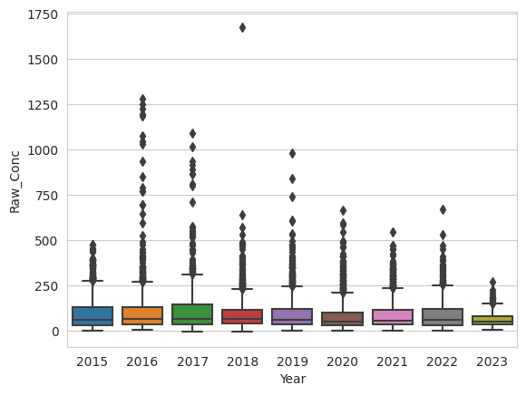

```python
sns.boxplot(x=dfNew_3.Year, y=dfNew_3.Raw_Conc, data=pd.melt(dfNew_3))

plt.show()
```

```python
Final_file=dfNew_3
```

```python
#Dropping all -999 rows as they will hinder with the data
#dfNew=df.replace(-999,np.nan)
Final_file.isna().sum()
```

```
index            0
Site             0
Parameter        0
Date_LT          0
Year             0
Month            0
Day              0
Hour             0
NowCast_Conc     0
AQI              0
AQI_Category    19
Raw_Conc         0
Conc_Unit        0
Duration         0
QC_Name          0
dtype: int64
```

```python
Final_file.dropna()
Final_file.shape
```

```
(8163, 15)
```

```python
Final_file.isna().sum()
```

```
index            0
Site             0
Parameter        0
Date_LT          0
Year             0
Month            0
Day              0
Hour             0
NowCast_Conc     0
AQI              0
AQI_Category    19
Raw_Conc         0
Conc_Unit        0
Duration         0
QC_Name          0
dtype: int64
```

```python
Final_file = Final_file.reset_index()
```

```python
index_aqi_ctg_na = Final_file[ (Final_file['AQI'] == -999) ].index
index_aqi_ctg_na
Final_file.drop(index_aqi_ctg_na , inplace=True)
print(f'New shape with dfNew is {Final_file.shape}')
```

```
New shape with dfNew is (8144, 16)
```

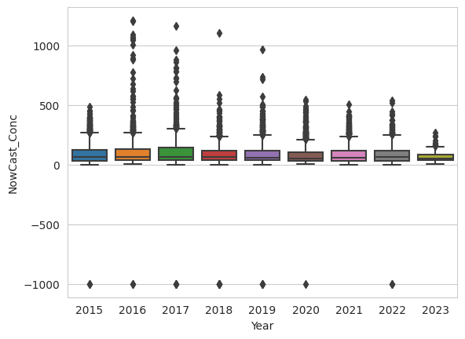

```python
sns.boxplot(x=dfNew_3.Year, y=dfNew_3.NowCast_Conc, data=pd.melt(dfNew_3))

plt.show()
```

Saving clean file

```python
Final_file.to_csv('clean_dataset.csv') #saving the file
```

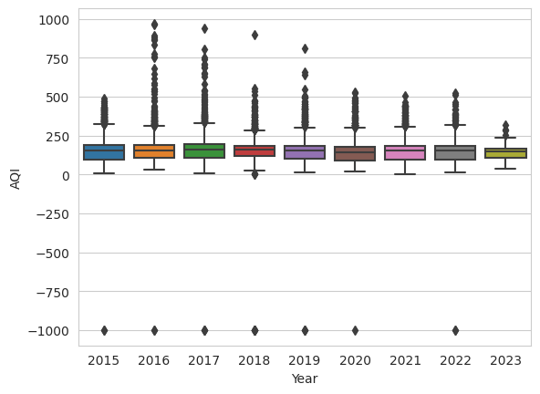

```python
sns.boxplot(x=dfNew_3.Year, y=dfNew_3.AQI, data=pd.melt(dfNew_3))

plt.show()
```

```python
#Checking any values less than 0 and dropping it as we cannot have less than 0 values.

index_less_zero_raw = Final_file[ (Final_file['Raw_Conc'] < 0) ].index
index_less_zero_now = Final_file[ (Final_file['NowCast_Conc'] < 0) ].index
index_less_zero_aqi = Final_file[ (Final_file['AQI'] < 0) ].index

print(f'index_less_zero_raw: {index_less_zero_raw}, index_less_zero_now: {index_less_zero_now} & index_less_zero_aqi: {index_less_zero_aqi}')
```

```
index_less_zero_raw: Int64Index([2651, 3617, 6189], dtype='int64'), index_less_zero_now: Int64Index([], dtype='int64') & index_less_zero_aqi: Int64Index([], dtype='int64')
```

## From above it is clear that only raw_conc has 3 values less than 0 and we need to drop it to make the data clearer for further evalution

```python
Final_file.drop(index_less_zero_raw , inplace=True)
print(f'New shape after removal is {Final_file.shape}')
```

```
New shape after removal is (8141, 16)
```

```python
Final_file.describe()
```

|  | level_0 | index | Year | Month | Day | Hour | NowCast_Conc | AQI | Raw_Conc |
| --- | --- | --- | --- | --- | --- | --- | --- | --- | --- |
| count | 8141.000000 | 8141.000000 | 8141.000000 | 8141.000000 | 8141.000000 | 8141.000000 | 8141.000000 | 8141.000000 | 8141.000000 |
| mean | 24631.362118 | 4854.286206 | 2018.639971 | 7.385088 | 15.754330 | 8.963518 | 96.872534 | 162.487532 | 95.832085 |
| std | 14176.528775 | 2209.103207 | 2.418239 | 3.045473 | 8.758181 | 6.725964 | 99.147926 | 88.568384 | 102.532819 |
| min | 1.000000 | 1300.000000 | 2015.000000 | 1.000000 | 1.000000 | 0.000000 | 0.700000 | 3.000000 | 0.000000 |
| 25% | 12348.000000 | 2897.000000 | 2017.000000 | 5.000000 | 8.000000 | 0.000000 | 36.000000 | 102.000000 | 34.000000 |
| 50% | 24739.000000 | 4632.000000 | 2019.000000 | 7.000000 | 16.000000 | 6.000000 | 62.300000 | 155.000000 | 60.000000 |
| 75% | 36895.000000 | 6864.000000 | 2021.000000 | 10.000000 | 23.000000 | 18.000000 | 121.500000 | 185.000000 | 120.000000 |
| max | 49077.000000 | 8783.000000 | 2023.000000 | 12.000000 | 31.000000 | 18.000000 | 1210.800000 | 969.000000 | 1676.000000 |

## From above it seems that min and max values are way too spaced out and needs filtering but first we will plot before removing anymore data

Plotting all the boxplot Yearly using Monthly Data.

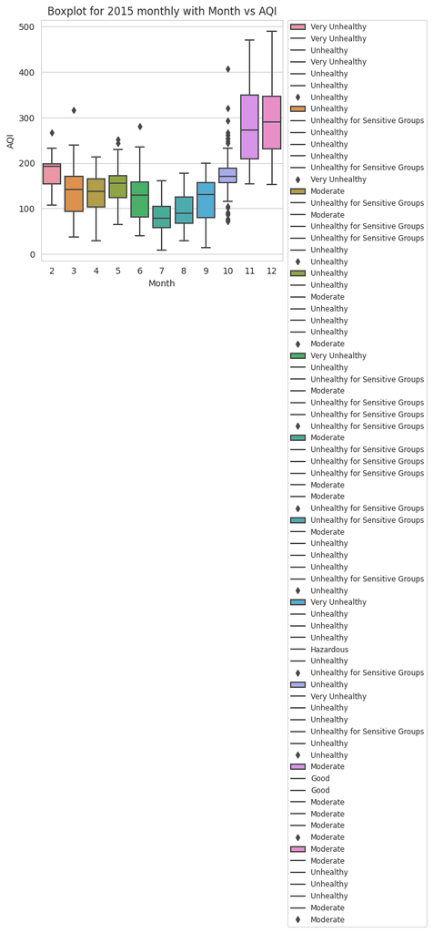

```python
#Boxplot for 2015 monthly

yearly_data_month_1 = Final_file[Final_file.Year == 2015]

plt.figure(figsize=(5, 5))
sns.boxplot(x='Month', y='value', data=pd.melt(yearly_data_month_1, id_vars=['Month'], value_vars=['AQI']))
plt.xlabel('Month')
plt.ylabel('AQI')
plt.title('Boxplot for 2015 monthly with Month vs AQI')
plt.legend(Final_file.AQI_Category,bbox_to_anchor=(1.02, 1), borderaxespad=0, fancybox=None, fontsize='small')


plt.show()
```

This boxplot tells me that there are 5 months with outliers and should be treated to get better understanding of the range. This one has Jan missing in the graph because it's data is not present. October has the lowest range and highest number of outliers while december has the longest range for whiskers and boxplot.

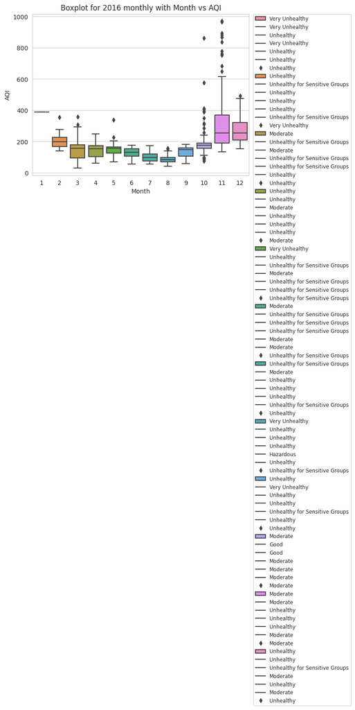

```python
#Boxplot for 2016 monthly

yearly_data_month_2 = Final_file[Final_file.Year == 2016]

#plt.figure(figsize=(5, 5))
sns.boxplot(x='Month', y='value', data=pd.melt(yearly_data_month_2, id_vars=['Month'], value_vars=['AQI']))
plt.xlabel('Month')
plt.ylabel('AQI')
plt.title('Boxplot for 2016 monthly with Month vs AQI')
plt.legend(Final_file.AQI_Category,bbox_to_anchor=(1.02, 1), borderaxespad=0, fancybox=None, fontsize='small')


plt.show()
```

This boxplot is for 2016 year and has 7 months which has outliers in which November has the highest number of outliers while Jan only has the median line without the plot. Addtionally, October has almost same numbers of outliers as November.

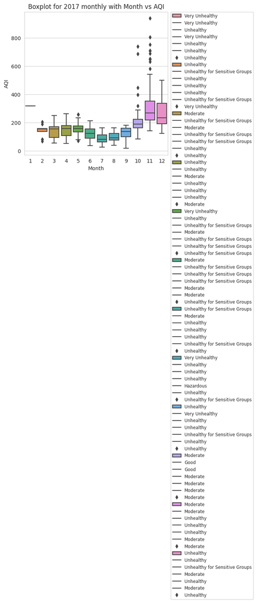

```python
#Boxplot for 2017 monthly

yearly_data_month_3 = Final_file[Final_file.Year == 2017]

plt.figure(figsize=(5, 5))
sns.boxplot(x='Month', y='value', data=pd.melt(yearly_data_month_3, id_vars=['Month'], value_vars=['AQI']))

plt.xlabel('Month')
plt.ylabel('AQI')
plt.title('Boxplot for 2017 monthly with Month vs AQI')
plt.legend(Final_file.AQI_Category,bbox_to_anchor=(1.02, 1), borderaxespad=0, fancybox=None, fontsize='small')


plt.show()
```

Here 4 months has outliers plotted with November being the highest with number of outliers. Next one is October with a much larger gap in outlers and Jan again has a median line plotted.

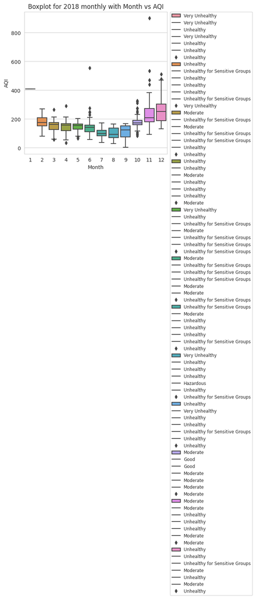

```python
#Boxplot for 2018 monthly

yearly_data_month_4 = Final_file[Final_file.Year == 2018]

plt.figure(figsize=(5, 5))
sns.boxplot(x='Month', y='value', data=pd.melt(yearly_data_month_4, id_vars=['Month'], value_vars=['AQI']))

plt.xlabel('Month')
plt.ylabel('AQI')
plt.title('Boxplot for 2018 monthly with Month vs AQI')
plt.legend(Final_file.AQI_Category,bbox_to_anchor=(1.02, 1), borderaxespad=0, fancybox=None, fontsize='small')

plt.show()
```

Here 7 months has outliers detected with Jan having a line for median plotted just above 400. June month has a wider range for outlier detected with boxplot ranging over 500 while November is above 800 which is much more than the average AQI of New Delhi of 300 AQI.

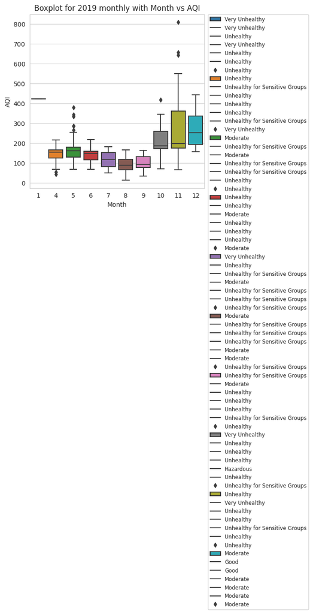

```python
#Boxplot for 2019 monthly

yearly_data_month_5 = Final_file[Final_file.Year == 2019]

plt.figure(figsize=(5, 5))
sns.boxplot(x='Month', y='value', data=pd.melt(yearly_data_month_5, id_vars=['Month'], value_vars=['AQI']))

plt.xlabel('Month')
plt.ylabel('AQI')
plt.title('Boxplot for 2019 monthly with Month vs AQI')
plt.legend(Final_file.AQI_Category,bbox_to_anchor=(1.02, 1), borderaxespad=0, fancybox=None, fontsize='small')

plt.show()
```

Here for 2019, we have 4 month with outliers detected using boxplot wherein November has the widest range for outlers exceeding 800 in AQI's value and Jan has a line for median plotted with just above 400 value.

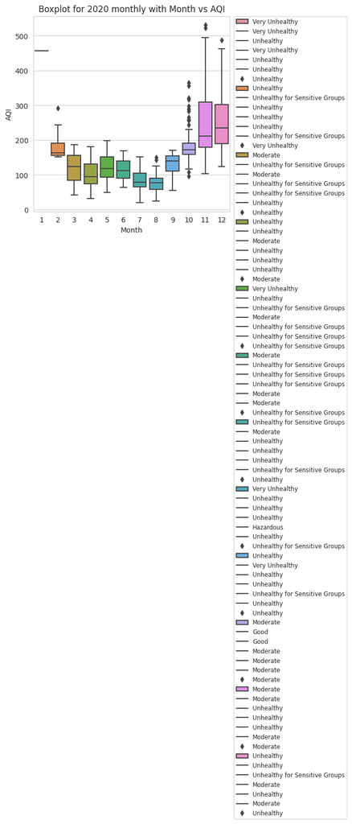

```python
#Boxplot for 2020 monthly

yearly_data_month_6 = Final_file[Final_file.Year == 2020]

plt.figure(figsize=(5, 5))
sns.boxplot(x='Month', y='value', data=pd.melt(yearly_data_month_6, id_vars=['Month'], value_vars=['AQI']))

plt.xlabel('Month')
plt.ylabel('AQI')
plt.title('Boxplot for 2020 monthly with Month vs AQI')
plt.legend(Final_file.AQI_Category,bbox_to_anchor=(1.02, 1), borderaxespad=0, fancybox=None, fontsize='small')

plt.show()
```

For 2020, 5 months has outliers with Jan again plotted as a median. October month has the highest numbers of outliers and November has the longest whisker range.

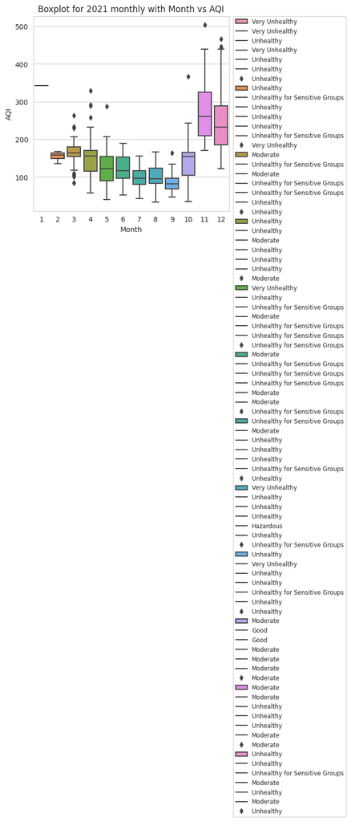

```python
#Boxplot for 2021 monthly

yearly_data_month_7 = Final_file[Final_file.Year == 2021]

plt.figure(figsize=(5, 5))
sns.boxplot(x='Month', y='value', data=pd.melt(yearly_data_month_7, id_vars=['Month'], value_vars=['AQI']))

plt.xlabel('Month')
plt.ylabel('AQI')
plt.title('Boxplot for 2021 monthly with Month vs AQI')
plt.legend(Final_file.AQI_Category,bbox_to_anchor=(1.02, 1), borderaxespad=0, fancybox=None, fontsize='small')

plt.show()
```

For 2021, except Month 2, 6, 7 & 8 rest all has outliers. February has the shortest range for whiskers and boxplot.

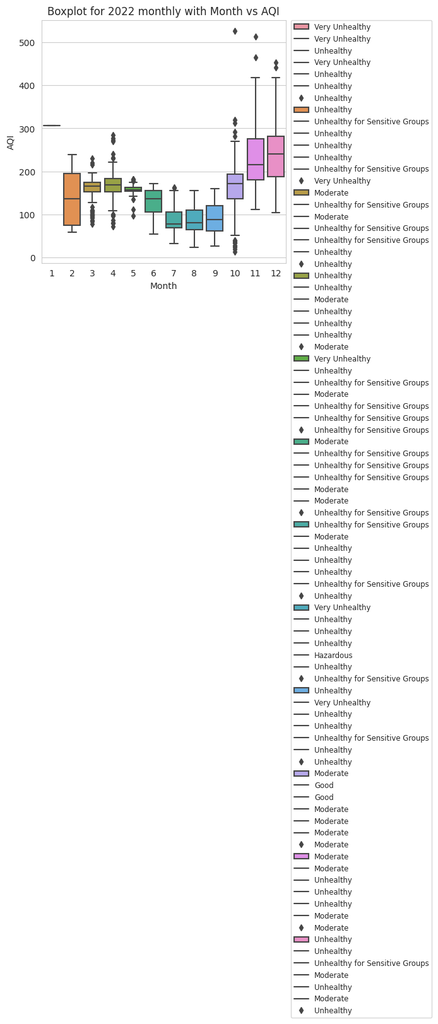

```python
#Boxplot for 2022 monthly

yearly_data_month_8 = Final_file[Final_file.Year == 2022]

plt.figure(figsize=(5, 5))
sns.boxplot(x='Month', y='value', data=pd.melt(yearly_data_month_8, id_vars=['Month'], value_vars=['AQI']))

plt.xlabel('Month')
plt.ylabel('AQI')
plt.title('Boxplot for 2022 monthly with Month vs AQI')
plt.legend(Final_file.AQI_Category,bbox_to_anchor=(1.02, 1), borderaxespad=0, fancybox=None, fontsize='small')

plt.show()
```

For 2022, except months 2, 6, 8 & 9 rest every month hsa few outliers. February has almost normal distribution plotted.

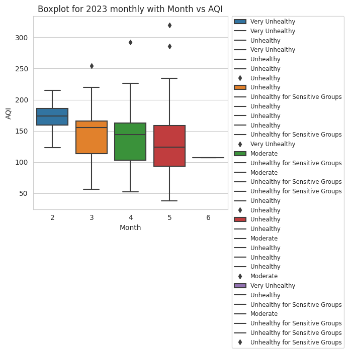

```python
#Boxplot for 2023 monthly

yearly_data_month_9 = Final_file[Final_file.Year == 2023]

plt.figure(figsize=(5, 5))
sns.boxplot(x='Month', y='value', data=pd.melt(yearly_data_month_9, id_vars=['Month'], value_vars=['AQI']))

plt.xlabel('Month')
plt.ylabel('AQI')
plt.title('Boxplot for 2023 monthly with Month vs AQI')
plt.legend(Final_file.AQI_Category,bbox_to_anchor=(1.02, 1), borderaxespad=0, fancybox=None, fontsize='small')

plt.show()
```

For 2023, Feb has a symmetrical distribution and June has a line plotted above.

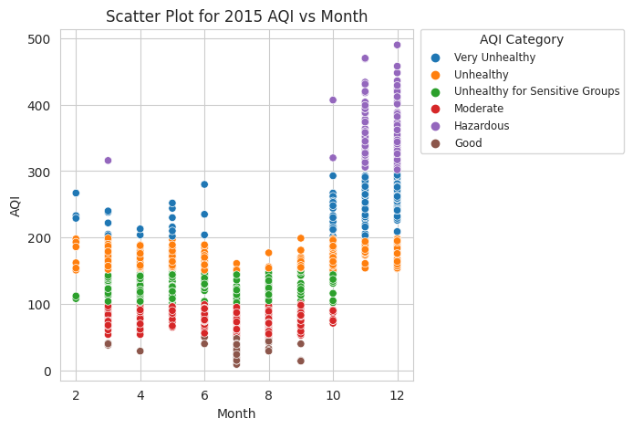

```python
#Scatterplot for 2015 monthly

plt.figure(figsize=(5, 5))
sns.set_style('whitegrid') #whitegrid, darkgrid, dark, white

scatter_monthly_1 = Final_file[Final_file['Year'] == 2015]

scatter_plot = sns.scatterplot(data=scatter_monthly_1, x='Month', y='AQI', hue='AQI_Category')
scatter_plot.set_title('Scatter Plot for 2015 AQI vs Month')
scatter_plot.legend(title='AQI Category', fontsize='small',bbox_to_anchor=(1.02, 1), borderaxespad=0, fancybox=None)

plt.show()
```

For 2015, Scatter plot shows an upward trend as we reach December. This does not has Jan month and december has the highest value for AQI about 500 falling within Hazardous category.

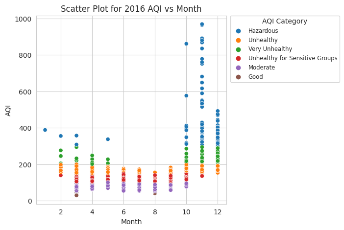

```python
#Scatterplot for 2016 monthly

plt.figure(figsize=(5, 5))
sns.set_style('whitegrid') #whitegrid, darkgrid, dark, white

scatter_monthly_2 = Final_file[Final_file['Year'] == 2016]

scatter_plot = sns.scatterplot(data=scatter_monthly_2, x='Month', y='AQI', hue='AQI_Category')
scatter_plot.set_title('Scatter Plot for 2016 AQI vs Month')
scatter_plot.legend(title='AQI Category', fontsize='small',bbox_to_anchor=(1.02, 1), borderaxespad=0, fancybox=None)

plt.show()
```

For 2016, Jan has 1 dot for AQI plotted whereas November has the highest AQI range of over 900 value for AQI.

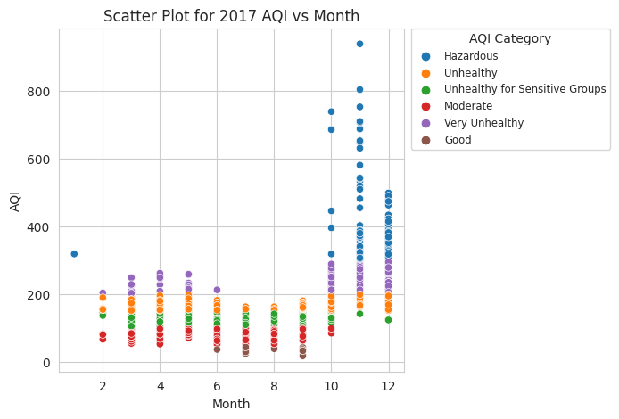

```python
#Scatterplot for 2017 monthly

plt.figure(figsize=(5, 5))
sns.set_style('whitegrid') #whitegrid, darkgrid, dark, white

scatter_monthly_3 = Final_file[Final_file['Year'] == 2017]

scatter_plot = sns.scatterplot(data=scatter_monthly_3, x='Month', y='AQI', hue='AQI_Category')
scatter_plot.set_title('Scatter Plot for 2017 AQI vs Month')
scatter_plot.legend(title='AQI Category', fontsize='small',bbox_to_anchor=(1.02, 1), borderaxespad=0, fancybox=None)

plt.show()
```

For 2017, plot has jan plotted for a dot whereas November again has values much higher than 800 falling within hazardous category.

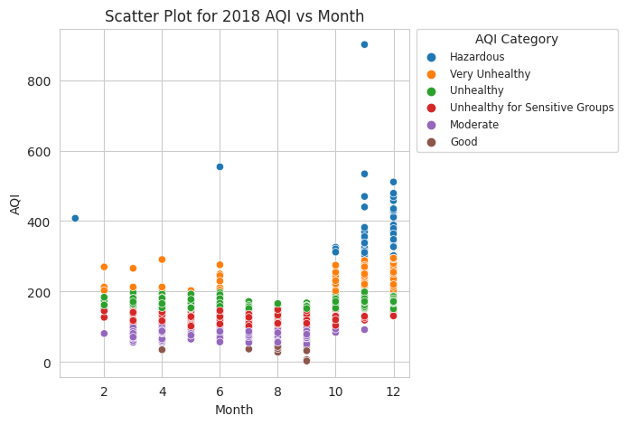

```python
#Scatterplot for 2018 monthly

plt.figure(figsize=(5, 5))
sns.set_style('whitegrid') #whitegrid, darkgrid, dark, white

scatter_monthly_4 = Final_file[Final_file['Year'] == 2018]

scatter_plot = sns.scatterplot(data=scatter_monthly_4, x='Month', y='AQI', hue='AQI_Category')
scatter_plot.set_title('Scatter Plot for 2018 AQI vs Month')
scatter_plot.legend(title='AQI Category', fontsize='small',bbox_to_anchor=(1.02, 1), borderaxespad=0, fancybox=None)

plt.show()
```

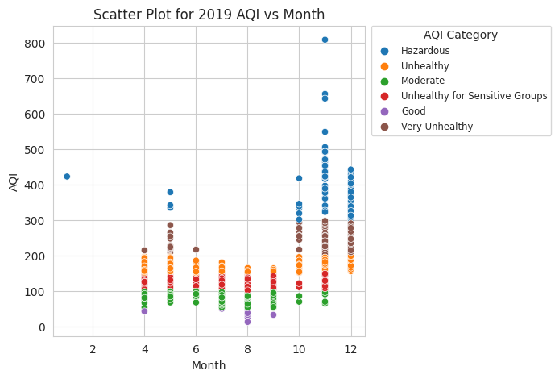

```python
#Scatterplot for 2019 monthly

plt.figure(figsize=(5, 5))
sns.set_style('whitegrid') #whitegrid, darkgrid, dark, white

scatter_monthly_5 = Final_file[Final_file['Year'] == 2019]

scatter_plot = sns.scatterplot(data=scatter_monthly_5, x='Month', y='AQI', hue='AQI_Category')
scatter_plot.set_title('Scatter Plot for 2019 AQI vs Month')
scatter_plot.legend(title='AQI Category', fontsize='small',bbox_to_anchor=(1.02, 1), borderaxespad=0, fancybox=None)

plt.show()
```

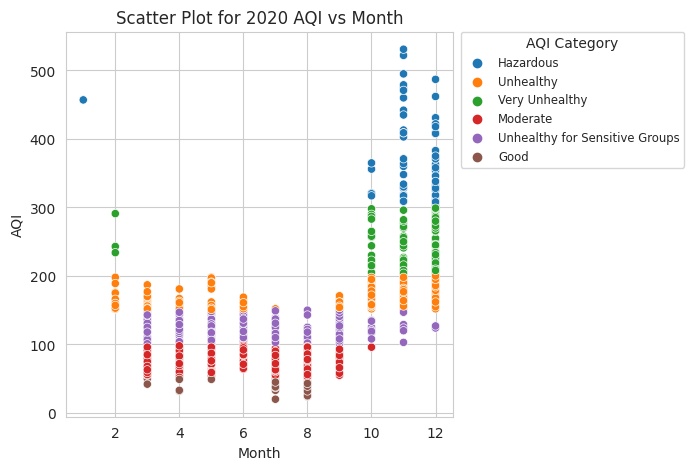

```python
#Scatterplot for 2020 monthly

plt.figure(figsize=(5, 5))
sns.set_style('whitegrid') #whitegrid, darkgrid, dark, white

scatter_monthly_6 = Final_file[Final_file['Year'] == 2020]

scatter_plot = sns.scatterplot(data=scatter_monthly_6, x='Month', y='AQI', hue='AQI_Category')
scatter_plot.set_title('Scatter Plot for 2020 AQI vs Month')
scatter_plot.legend(title='AQI Category', fontsize='small',bbox_to_anchor=(1.02, 1), borderaxespad=0, fancybox=None)

plt.show()
```

For 2020, trend seems to be increasing with November having the highest above 500 value and Jan is almost up with November and December.

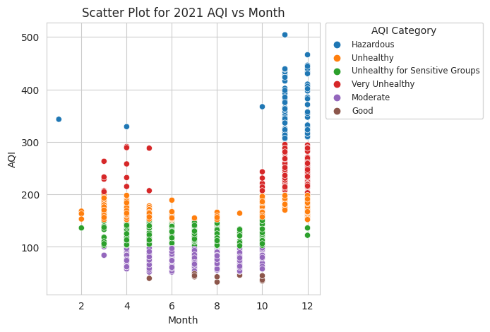

```python
#Scatterplot for 2021 monthly

plt.figure(figsize=(5, 5))
sns.set_style('whitegrid') #whitegrid, darkgrid, dark, white

scatter_monthly_7 = Final_file[Final_file['Year'] == 2021]

scatter_plot = sns.scatterplot(data=scatter_monthly_7, x='Month', y='AQI', hue='AQI_Category')
scatter_plot.set_title('Scatter Plot for 2021 AQI vs Month')
scatter_plot.legend(title='AQI Category', fontsize='small',bbox_to_anchor=(1.02, 1), borderaxespad=0, fancybox=None)

plt.show()
```

For 2021, the trend seems to be upwards with exceptions for middle order from May till September and November has the highest value above 500.

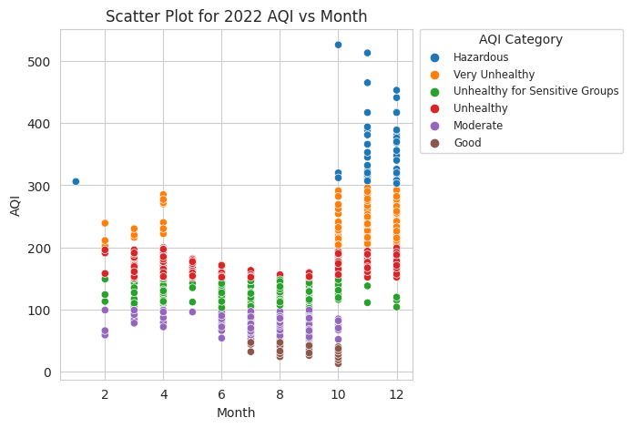

```python
#Scatterplot for 2022 monthly

plt.figure(figsize=(5, 5))
sns.set_style('whitegrid') #whitegrid, darkgrid, dark, white

scatter_monthly_8 = Final_file[Final_file['Year'] == 2022]

scatter_plot = sns.scatterplot(data=scatter_monthly_8, x='Month', y='AQI', hue='AQI_Category')
scatter_plot.set_title('Scatter Plot for 2022 AQI vs Month')
scatter_plot.legend(title='AQI Category', fontsize='small',bbox_to_anchor=(1.02, 1), borderaxespad=0, fancybox=None)

plt.show()
```

For 2022, October has the highest value falling withing Hazardous category.

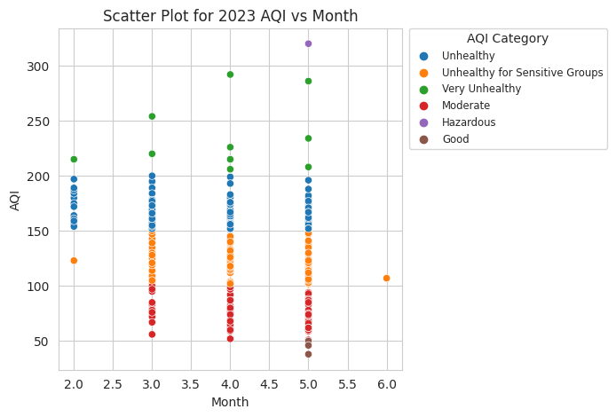

```python
#Scatterplot for 2023 monthly

plt.figure(figsize=(5, 5))
sns.set_style('whitegrid') #whitegrid, darkgrid, dark, white

scatter_monthly_9 = Final_file[Final_file['Year'] == 2023]

scatter_plot = sns.scatterplot(data=scatter_monthly_9, x='Month', y='AQI', hue='AQI_Category')
scatter_plot.set_title('Scatter Plot for 2023 AQI vs Month')
scatter_plot.legend(title='AQI Category', fontsize='small',bbox_to_anchor=(1.02, 1), borderaxespad=0, fancybox=None)

plt.show()
```

For 2023, May has the highest value of above 300 falling withing hazardous category.

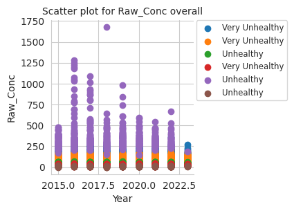

```python
#Scatter plot for Raw_Conc

plt.figure(figsize=(10,10))
sns.set_style('whitegrid')  #whitegrid, darkgrid, dark, white
sns.FacetGrid(Final_file, hue='AQI_Category').map(plt.scatter,'Year','Raw_Conc')
plt.title('Scatter plot for Raw_Conc overall',fontsize='medium')

plt.legend(Final_file.AQI_Category,bbox_to_anchor=(1.02, 1), borderaxespad=0, fancybox=None, fontsize='small')

plt.show()
```

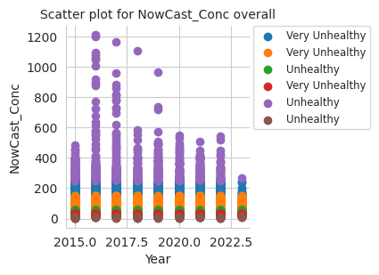

```python
#Scatter plot for NowCast_Conc

plt.figure(figsize=(10,10))
sns.set_style('whitegrid')  #whitegrid, darkgrid, dark, white
sns.FacetGrid(Final_file, hue='AQI_Category').map(plt.scatter,'Year','NowCast_Conc')
plt.title('Scatter plot for NowCast_Conc overall',fontsize='medium')

plt.legend(Final_file.AQI_Category,bbox_to_anchor=(1.02, 1), borderaxespad=0, fancybox=None, fontsize='small')

plt.show()
```

Plotting all the Histogram graphs Yearly using Monthly Data.

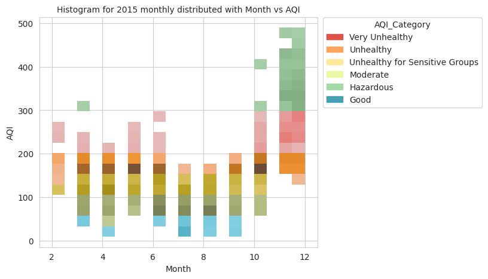

```python
#Histogram for 2015 monthly distributed with Month vs AQI

fig = plt.figure(figsize=(6,5))

hist_monthly_1 = Final_file[Final_file['Year'] == 2015]

plt.title('Histogram for 2015 monthly distributed with Month vs AQI',fontsize='medium')

ax = sns.histplot(data=hist_monthly_1,x=Final_file.Month, y=Final_file.AQI, palette = "Spectral",hue="AQI_Category", bins=20, legend='auto')
sns.move_legend(ax, "upper left", bbox_to_anchor=(1.02, 1),borderaxespad=0)

plt.show()
```

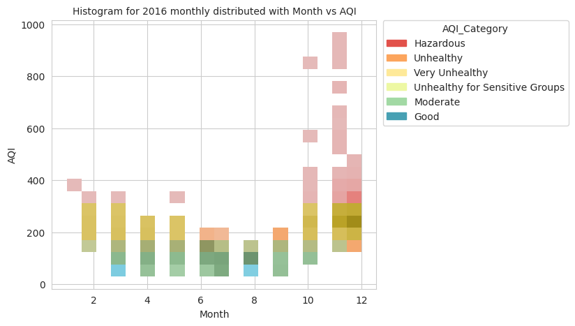

```python
#Histogram for 2016 monthly distributed with Month vs AQI

fig = plt.figure(figsize=(6,5))

hist_monthly_2 = Final_file[Final_file['Year'] == 2016]

plt.title('Histogram for 2016 monthly distributed with Month vs AQI',fontsize='medium')

ax = sns.histplot(data=hist_monthly_2,x=Final_file.Month, y=Final_file.AQI, palette = "Spectral", hue="AQI_Category",bins=20, legend='auto')
sns.move_legend(ax, "upper left", bbox_to_anchor=(1.02, 1),borderaxespad=0)

plt.show()
```

For 2016, histogram shows that it was almost unhealthy category around the year.

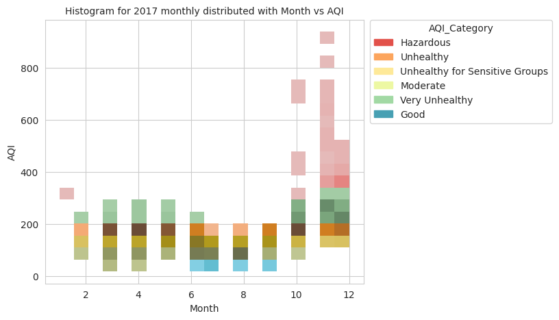

```python
#Histogram for 2017 monthly distributed with Month vs AQI

fig = plt.figure(figsize=(6,5))

hist_monthly_3 = Final_file[Final_file['Year'] == 2017]

plt.title('Histogram for 2017 monthly distributed with Month vs AQI',fontsize='medium')

ax = sns.histplot(data=hist_monthly_3,x=Final_file.Month, y=Final_file.AQI, palette = "Spectral", hue="AQI_Category",bins=20, legend='auto')
sns.move_legend(ax, "upper left", bbox_to_anchor=(1.02, 1),borderaxespad=0)

plt.show()
```

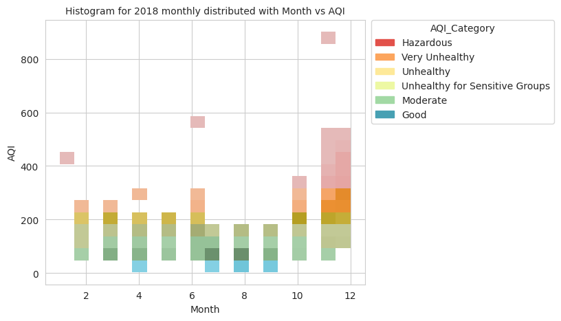

```python
#Histogram for 2018 monthly distributed with Month vs AQI

fig = plt.figure(figsize=(6,5))

hist_monthly_4 = Final_file[Final_file['Year'] == 2018]

plt.title('Histogram for 2018 monthly distributed with Month vs AQI',fontsize='medium')

ax = sns.histplot(data=hist_monthly_4,x=Final_file.Month, y=Final_file.AQI, palette = "Spectral", hue="AQI_Category",bins=20, legend='auto')
sns.move_legend(ax, "upper left", bbox_to_anchor=(1.02, 1),borderaxespad=0)

plt.show()
```

For 2018, it seems that the distribution is upwards with left skewed.

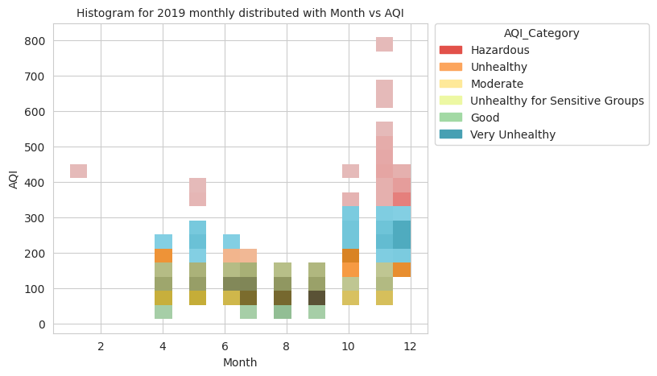

```python
#Histogram for 2019 monthly distributed with Month vs AQI

fig = plt.figure(figsize=(6,5))

hist_monthly_5 = Final_file[Final_file['Year'] == 2019]

plt.title('Histogram for 2019 monthly distributed with Month vs AQI',fontsize='medium')

ax = sns.histplot(data=hist_monthly_5,x=Final_file.Month, y=Final_file.AQI, palette = "Spectral", hue="AQI_Category",bins=20, legend='auto')
sns.move_legend(ax, "upper left", bbox_to_anchor=(1.02, 1),borderaxespad=0)

plt.show()
```

For 2019, histogram seems to be bimodial distribution.